# Checks Report

### Health facility data quality assessment: numerators

**BACKGROUND:** Routinely reported health facility data are an important data source for health indicators. The data are reported by health facilities on events such as immunizations given, or live births attended. As with any data, quality is an issue. Data are checked to consider completeness of reporting by health facilities, identify extreme outliers and internal consistency.

**Table 1a: Summary of data quality for reported immunization health facility data**

| no | Data Quality Metrics | 2019 | 2020 | 2021 | 2022 | 2023 |
| --- | --- | --- | --- | --- | --- | --- |
| 1. Completeness of monthly facility reporting (Immunization) |  |  |  |  |  |  |
| 1a | % of expected monthly facility reports (national) | 94.0 | 96.0 | 96.0 | 97.0 | 97.0 |
| 1b | % of districts with completeness of facility reporting >= 90% | 80.0 | 92.0 | 98.0 | 94.0 | 98.0 |
| 1c | % of districts with no missing values (mean for common vaccines) | 50.0 | 100.0 | 100.0 | 100.0 | 100.0 |
| 2. Extreme outliers (Common Vaccine antigens) |  |  |  |  |  |  |
| 2a | % of monthly values that are not extreme outliers (national) | 99.6 | 97.7 | 99.1 | 99.9 | 93.0 |
| 2b | % of districts with no extreme outliers in the year | 96.8 | 79.3 | 90.7 | 98.7 | 89.6 |
| 3. Consistency of annual reporting |  |  |  |  |  |  |
| 3a | Ratio anc1/penta1 | 1.0328 | 1.1059 | 1.0827 | 1.0563 | 1.0580 |
| 3b | Ratio penta1/penta3 | 1.0562 | 1.0461 | 1.0660 | 1.0378 | 1.0447 |
| 3c | Ratio opv1/opv3 | NaN | 1.0480 | 1.0690 | 1.0441 | 1.0450 |
| 3f | % district with anc1/penta1 in expected ranged | 70.2 | 95.7 | 91.5 | 87.2 | 85.1 |
| 3g | % district with penta1/penta3 in expected ranged | 93.6 | 89.4 | 97.9 | 87.2 | 93.6 |
| 3h | % district with opv1/opv3 in expected ranged | NaN | 95.7 | 97.9 | 89.4 | 93.6 |
| 4 | Annual data quality score | 83.5 | 93.2 | 96.4 | 94.2 | 93.7 |

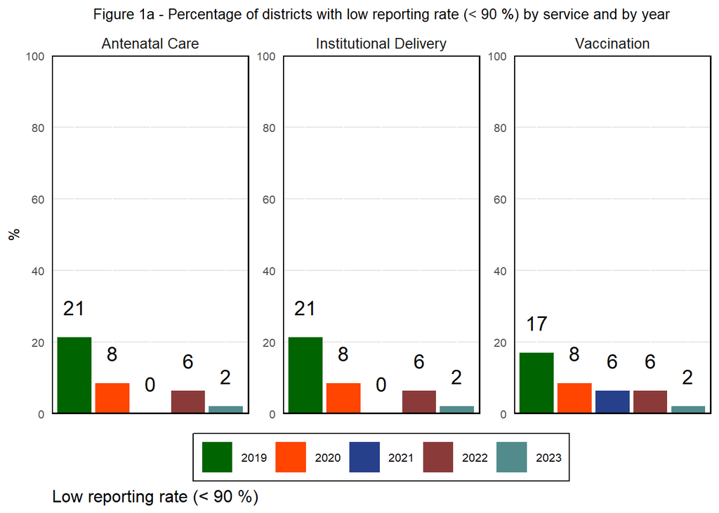

### Health facility data quality assessment: numerators

**BACKGROUND:** Routinely reported health facility data are essential for monitoring immunization coverage. Data quality assessments often reveal discrepancies in the Penta1/Penta3 ratio, which should ideally be close to 1.

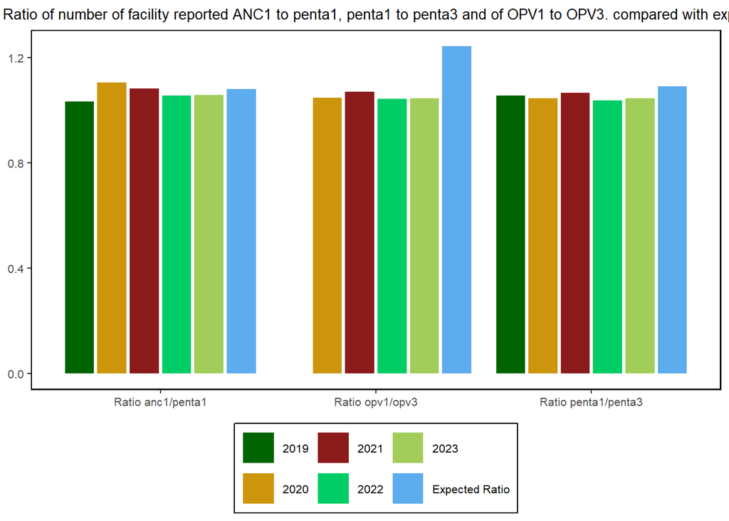

### Health facility data adjustment: Numerators - reported live births and Pentavalent 1 doses

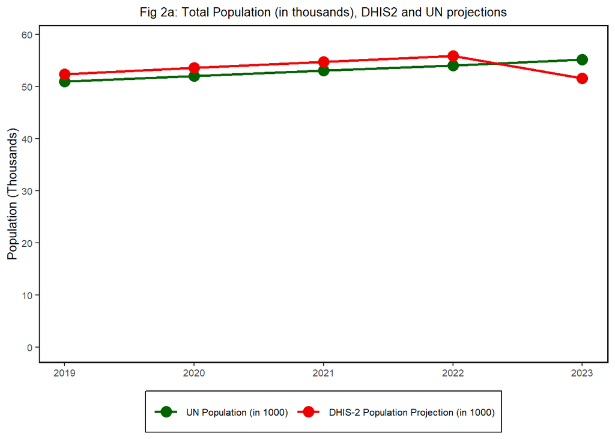

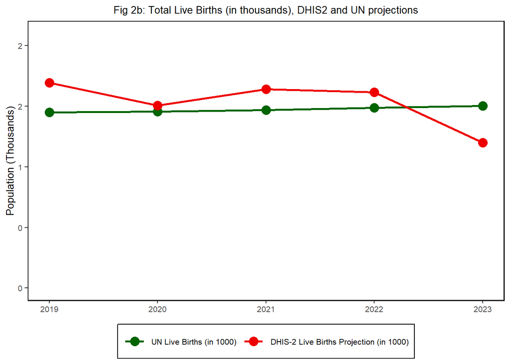